# index

Traqueostomias

em desmame ventilatório

Gonçalo Torrinha, MD

Serviço de Medicina Intensiva, Hospital de Braga Escola de Medicina, Universidade do Minho

## Porque é que mantemos doentes ventilados?

Classificações ICC e WIND de desmame ventilatório, adaptado<sup>1</sup>

| Classificação | ICC | WIND |
| --- | --- | --- |
| Grupo NW/0 | - | Desmame não tentado |
| Grupo 1 | “Simples”: sucesso após primeiro SBT | “Curto”: sucesso ou morte em < 24h |
| Grupo 2 | “Difícil”: ≤ 3 SBTs + < 7 dias | “Difícil”: sucesso ou morte entre 1 a 7 dias |
| Grupo 3 | “Prolongado”: > 3 SBTs ou > 7 dias | “Prolongado”: insucesso ou morte >7 dias *após primeira tentativa* |

[^1]: Dolinay et al. Journal of Clinical Medicine 2024. DOI: 10.3390/jcm13071909

## Porque é que mantemos doentes ventilados?

- Dois grandes grupos de falência de Desmame:
  1. **Falência Ventilatória**
  2. **Falência de Via Aérea e de estímulo ventilatório**

## Porque é que mantemos doentes ventilados?

1. **…por Falência Ventilatória**
   - Grupos 2 e 3<sup>1</sup>; associados a:
     - fadiga de músculos respiratórios,
     - esforço respiratório aumentado
     - patologia sistémica. <sup>2</sup>
[^2]: Ghiani et al. BMC Pulmonary Medicine 2026. DOI: 10.1186/s12890-026-04252-9
[^3]: Shah et al. Breathe 2024. DOI: 10.1183/20734735.0122-2024

## Porque é que mantemos doentes ventilados?

2. **…por Falência de Via Aérea e de estímulo ventilatório**
   - Grupo NW/0: pulmões “intactos”, mas ausência de proteção de via aérea ou colaboração neurológica em SBT<sup>1</sup>
   - Falência de Extubação (<48 a 72h): +++ *obstrução de VA*, tosse ineficaz, disfagia/disfunção de sensibilidade laríngea ou carga elevada de secreções<sup>2</sup>
     - Post-Extubation Respiratory Failure (PERF): re-intubação <7 dias<sup>3</sup>
       - Insuficiência respiratória pós-extubação
       - +++ *fadiga respiratória*, carga elevada de secreções, ou *sobrecarga hídrica ± disfunção cardíaca*
[^4]: Dziewas et al. Neurological Research and Practice 2025. DOI: 10.1186/s42466-025-00376-1
[^5]: Medrinal et al. Annals of Intensive Care 2026. DOI: 10.1016/j.aicoj.2026.100045
[^6]: Shah et al. Breathe 2024. DOI: 10.1183/20734735.0122-2024

## Morbi-mortalidade do desmame ventilatório<sup>1</sup><sup>,</sup><sup>2</sup><sup>,</sup><sup>3</sup><sup>,</sup><sup>4</sup><sup>,</sup><sup>5</sup>

- Prevalência:
  - Ventilação: 20 a 31% da generalidade dos doentes críticos
  - Via aérea/estímulo ventilatório: 14 a 18% na generalidade dos doentes, mas 15% a 47% dos doentes neurocríticos
- Mortalidade:
  - Falência de desmame: entre 24 a 39%, a 12 meses 40 a 75%
  - Falência de extubação associada a >2x mortalidade
- LOS (mediana): 22 a 25 dias em SMI, 45 a 51 dias no Hospital.
[^7]: Shah et al. Breathe 2024. DOI: 10.1183/20734735.0122-2024
[^8]: Ghiani et al. BMC Pulmonary Medicine 2026. DOI: 10.1186/s12890-026-04252-9
[^9]: Alghamdi et al. The Egyptian Journal of Bronchology 2026. DOI:10.1186/s43168-026-00521-7
[^10]: Medrinal et al. Annals of Intensive Care 2026. DOI: 10.1016/j.aicoj.2026.100045
[^11]: Dziewas et al. Neurological Research and Practice 2025. DOI: 10.1186/s42466-025-00376-1

## O problema de decisão

Traqueostomia:

**1. O doente *necessita*?**

**2. Quando?**

**3. Como?**

## Para quê?

- Redução de espaço morto e trabalho respiratório (WOB)
  - Menos *espaço-morto*: redução em 30 a 50%<sup>1</sup>
  - Menos resistência de via aérea:
    - Maior calibre e menor comprimento
    - Menor compromisso por compressão externa<sup>2</sup>
[^14]: Amada et al. British Journal of Hospital Medicine 2026. DOI: 10.31083/BJHM50155
[^15]: Ghattas et al. Journal of Thoracic Disease 2021. DOI: 10.21037/jtd-19-4121

## Para quê?

- Redução de espaço morto e trabalho respiratório (WOB)

$$\Delta P \propto \frac{L}{r^4}$$

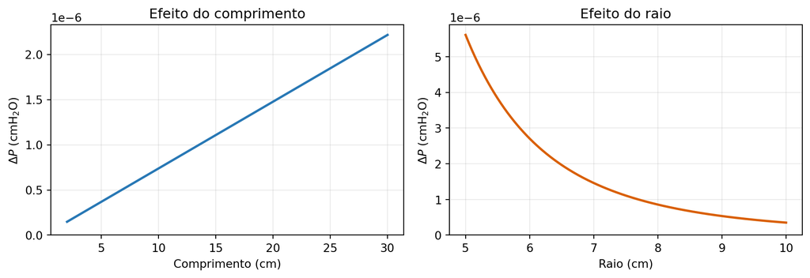

## Para quê?

- Redução de espaço morto e trabalho respiratório (WOB)
- Otimização na gestão de S/A e Delirium
  - Menor reatividade ao tubo → desmame de sedo-analgesia mais precoce<sup>1</sup>
- Margem para reabilitação
  - Retorno prococe de fonação (cânula fonatória ou *cuff* desinsuflado)<sup>2</sup> e mobilização precoce<sup>3</sup>
  - Retorno precoce de deglutição (*cuff* e mobilidade laríngea)<sup>4</sup> → Efeito indireto por prevenção de delirium
- Correta *toilette* brônquica: aspirações subglóticas → mais eficazes^3
- Prevenção de trauma de CV e aritnóides → menos complicações anatómicas<sup>1</sup>
[^16]: Alghamdi et al. The Egyptian Journal of Bronchology 2026. DOI:10.1186/s43168-026-00521-7
[^17]: Amada et al. British Journal of Hospital Medicine 2026. DOI: 10.31083/BJHM50155
[^18]: Medrinal et al. Annals of Intensive Care 2026. DOI: 10.1016/j.aicoj.2026.100045
[^19]: Ghattas et al. Journal of Thoracic Disease 2021. DOI: 10.21037/jtd-19-4121

## Para quê? E quando? → *TracMan Trial*<sup>1</sup>

- JAMA 2013
- Reino Unido, 2004 a 2011
- 70 UCIP + 2UCIP Cirurgia Cardíaca
- 1032 doentes elegíveis → 889 analisados:
  - <4 dias de VMI à data de seleção
  - clinicamente com potencial de necessitar de >7 dias de VMI
- Dois grupos randomizados: traqueostomias ≤4 dias *versus* >10 dias
[^20]: Young et al. The TracMan Randomized Trial. JAMA 2013. DOI:10.1001/jama.2013.5154

## Para quê? E quando? → *TracMan Trial*<sup>1</sup>

- 2004 a 2011, 889 analisados
- Traqueostomias ≤4 dias *versus* >10 dias
- Resultados:
  - Mortalidade a 30 dias: ~31% em ambos, p>0.5
    - Sem diferenças à alta de SMI, hospitalar, 12 e 24 meses
  - LOS: semelhante.
  - Dias livres de antibiótico: semelhante.
  - **Duração de sedação (mediana): 5 *versus* 8 dias**, p<0.001
[^21]: Young et al. The TracMan Randomized Trial. JAMA 2013. DOI:10.1001/jama.2013.5154

## Para quê? E quando?

*TracMan Trial*<sup>1</sup>: o único RCT, resultados debatíveis

- Exclusão explícita de doentes neurocríticos
  - *because our study centers indicated these patients usually receive early tracheostomies*
- 53.7% (244/454) do grupo tardio **nunca** foi traqueostomizado
  - 167 recuperaram espontaneamente → extubados → alta
- Análise de dias de antibiótico, sem análise de pneumonias associada a tubo
[^22]: Young et al. The TracMan Randomized Trial. JAMA 2013. DOI:10.1001/jama.2013.5154

## O problema de decisão

Traqueostomia:

1. O doente *necessita*?
2. Quando?
3. Como?
4. Quando e como **parar**?